# Effect of Treatments on Glottic Cancer

Xiang Zhu & Shutian Lin (Group 6)

August 03, 2021

```r
library(tidyverse)
library(readxl)
library(table1)
library(magrittr)
library(dplyr)

glottic <- read_excel("Glottic_Cancer_Data_Set_011521.xlsx")

# Check for missing value for each column
apply(glottic, 2, function(x) {
    sum(is.na(x))
})
```

[output not shown]

```r
glottic <- glottic %>%
    filter(Death_Status != 1) %>%
    filter(!is.na(Age_dx)) %>%
    filter(Rad_Tx_Status != "U", Rad_Tx_Status == "0.00" | Rad_Tx_Status ==
        "1.00") %>%
    mutate(Rad_Tx_Status = as.numeric(Rad_Tx_Status)) %>%
    mutate(Death_Status = ifelse(Death_Status == 0, 0, 1)) %>%
    mutate(Race = ifelse(Race == "Black" | Race == "White", Race,
        "Others")) %>%
    rename(Tumor_Type = Derived_AJCC, Age = Age_dx) %>%
    select(-Survival_mos)
glottic %<>%
    mutate_each_(funs(factor(.)), c("Tumor_Type", "Sex", "Race",
        "Rad_Tx_Status", "Death_Status"))
```

```r
# Descriptive table of all variables stratified by death
# status
table1 <- table1(~Tumor_Type + Sex + Age + Race + Rad_Tx_Status |
    Death_Status, data = glottic)
```

### Description of the problem and scientific question

As one of the most common head and neck malignancies, glottic cancer makes up about 1% of global cancer in 2018 and causes 1% of the cancer deaths worldwide. Treatments for this type of cancer mainly involve surgery, radiation, or a combination of both surgery and radiation. The scientific question for this study is that: What is the effect of different types of treatments on the three-year survival among patients with glottic cancer?

### Description of the dataset

#### Data definitions

- Tumor_Type: American Joint Committee on Cancer staging classification system
  - T1a and T1b: The tumor is only in the vocal cords with normal mobility. T1a refers to cancer involvement of only one cord. T1b refers to cancer involvement of both cords.
  - T2: The tumor is large enough that it goes to the supraglottis and/or subglottis, and/or there is decreased movement of the vocal cord.
  - T1NOS: T1 tumor not otherwise specified.
- Sex: Female/Male
- Age: in years
- Race: White/Black/Others
- Rad_Tx_Status: Radiation/Surgery treatment status
  - 0 = Surgery
  - 1 = Radiation
- Death_Status: status at endpoint
  - 0 = Alive
  - 1 = Dead Cancer

#### Description of variables

```r
table1
```

|  | 0 (N=2460) | 1 (N=161) | Overall (N=2621) |
| --- | --- | --- | --- |
| Tumor_Type |  |  |  |
| T1a | 1164 (47.3%) | 55 (34.2%) | 1219 (46.5%) |
| T1b | 236 (9.6%) | 19 (11.8%) | 255 (9.7%) |
| T1NOS | 476 (19.3%) | 17 (10.6%) | 493 (18.8%) |
| T2 | 584 (23.7%) | 70 (43.5%) | 654 (25.0%) |
| Sex |  |  |  |
| Female | 273 (11.1%) | 21 (13.0%) | 294 (11.2%) |
| Male | 2187 (88.9%) | 140 (87.0%) | 2327 (88.8%) |
| Age |  |  |  |
| Mean (SD) | 63.8 (11.4) | 67.2 (12.8) | 64.0 (11.6) |
| Median [Min, Max] | 64.0 [16.0, 93.0] | 67.0 [42.0, 106] | 64.0 [16.0, 106] |
| Race |  |  |  |
| Black | 281 (11.4%) | 18 (11.2%) | 299 (11.4%) |
| Others | 113 (4.6%) | 5 (3.1%) | 118 (4.5%) |
| White | 2066 (84.0%) | 138 (85.7%) | 2204 (84.1%) |
| Rad_Tx_Status |  |  |  |
| 0 | 553 (22.5%) | 23 (14.3%) | 576 (22.0%) |
| 1 | 1907 (77.5%) | 138 (85.7%) | 2045 (78.0%) |

#### Correlation between variables

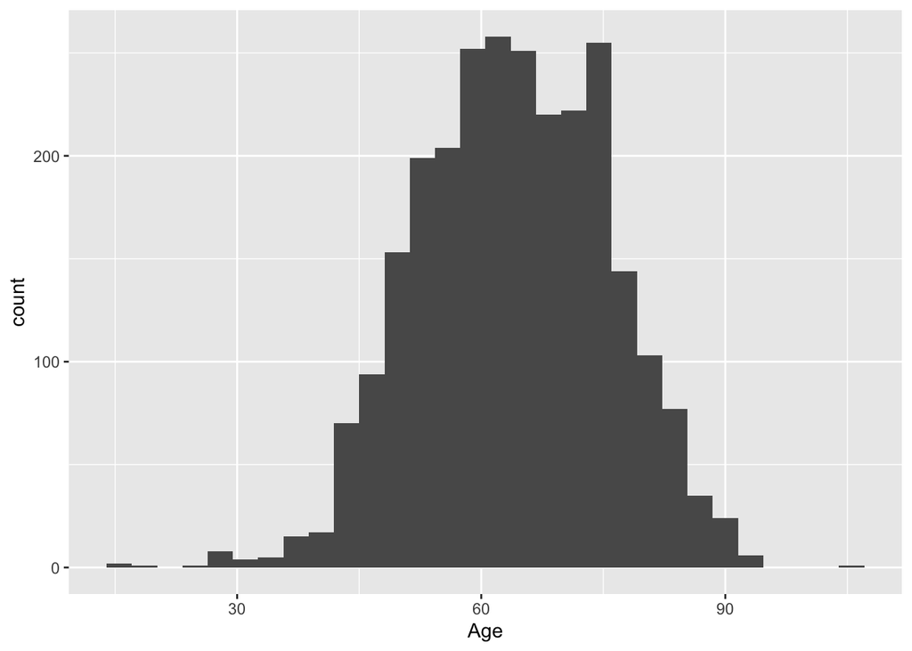

```r
ggplot(glottic, aes(Age)) + geom_histogram(bins = 30)
```

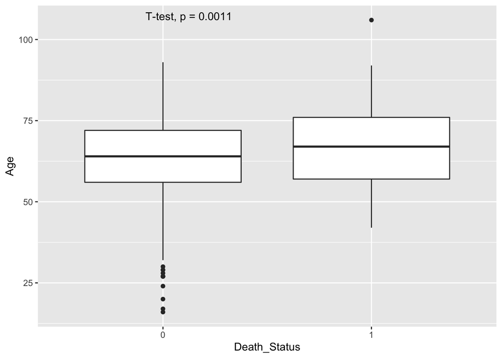

```r
library(ggpubr)
# Tumor_Type + Sex + Age + Race + Rad_Tx_Status |
# Death_Status
ggplot(glottic, aes(x = Death_Status, y = Age)) + geom_boxplot(add = "jitter") +
    stat_compare_means(method = "t.test")
```

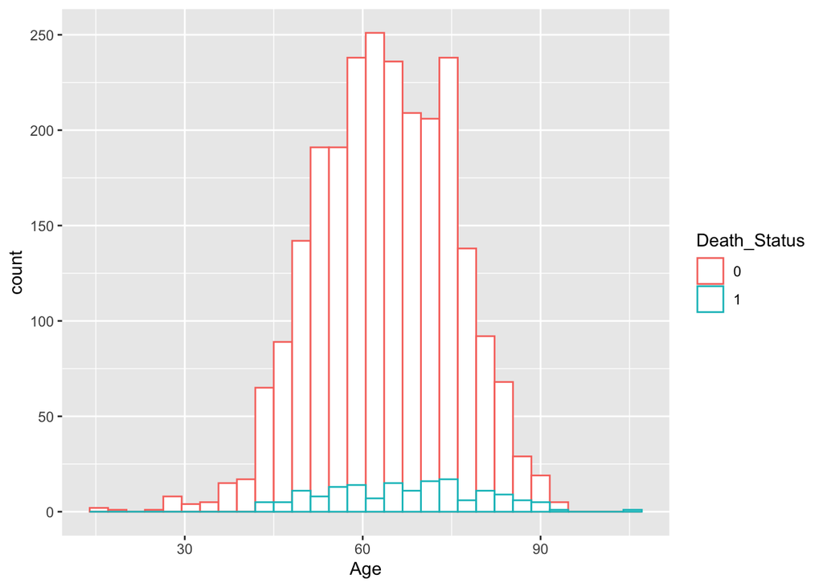

```r
ggplot(glottic, aes(x = Age, color = Death_Status)) + geom_histogram(bins = 30,
    position = "identity", fill = "white")
```

```r
# Tumor_Type
chisq.test(glottic$Death_Status, glottic$Tumor_Type)
```

```
##
##  Pearson's Chi-squared test
##
## data:  glottic$Death_Status and glottic$Tumor_Type
## X-squared = 36.182, df = 3, p-value = 6.852e-08
```

```r
# Sex
chisq.test(glottic$Death_Status, glottic$Sex)
```

```
##
##  Pearson's Chi-squared test with Yates' continuity correction
##
## data:  glottic$Death_Status and glottic$Sex
## X-squared = 0.39577, df = 1, p-value = 0.5293
```

```r
# Race
chisq.test(glottic$Death_Status, glottic$Race)
```

```
##
##  Pearson's Chi-squared test
##
## data:  glottic$Death_Status and glottic$Race
## X-squared = 0.80469, df = 2, p-value = 0.6688
```

```r
# Rad_Tx_Status
chisq.test(glottic$Death_Status, glottic$Rad_Tx_Status)
```

```
##
##  Pearson's Chi-squared test with Yates' continuity correction
##
## data:  glottic$Death_Status and glottic$Rad_Tx_Status
## X-squared = 5.4488, df = 1, p-value = 0.01958
```

### 1. Specify a Causal Model.

- Endogenous variables: $X=(W_1, W_2, W_3, W_4, A,Y)$
- Exogenous variables: $U=(U_{W_1},U_{W_2}, U_{W_3}, U_{W_4}, U_A,U_Y)∼P^∗$
- Structural equations F:

$$W_1 <- f_W(U_{W_1})$$
$$W_2 <- f_W(U_{W_2})$$
$$W_3 <- f_W(U_{W_3})$$
$$W_4 <- f_W(W_1， W_2， W_3，U_{W_4})$$
$$A <- f_W(U_A, W_3, W_4)$$
$$Y <- f_W(U_Y, A, W_3, W_4)$$

where $W_1$={Female, Male}, $W_2$={Black, White, Others}, $W_3$={Age}, $W_4$={T1a, T1b, T1NOS, T2}, $A$={Surgery, Radiation}, $Y$={survival}.

### 2. Translate your question into a formal target causal parameter, defined using counter-factuals.

The target causal parameter is the difference in the counterfactual vital status through three years, if all subjects take the treatment of Radiation, and the counterfactual vital status, if all subjects take the treatment of Surgery:

$$P^*(Y_1 = 1) - P^*(Y_0 = 1) = E^*[Y_1] - E^*[Y_0]$$
where $Y_a$ denotes the counterfactual outcome under an intervention to set treatment status $A=a$.

### 3. Specify your observed data and its link to the causal model.

The observed data is $O=(W_1, W_2, W_3, W_4, A,Y)$, where $W_1$={Female, Male}, $W_2$={Black, White, Others}, $W_3$={Age}, $W_4$={T1a, T1b, T1NOS, T2}, $A$={Surgery, Radiation}, $Y$={survival}.

### 4. Identify.

In the SCM, the target causal quantity is not identified. If we have more information to have $U_A$ independent on other U, the back-door criterion holds conditional on $W = (W_3, W_4)$. Equivalently, the counterfactual outcome $Y_a$ is conditionally independent of the treatment A, given $W = (W_3, W_4)$.

For identifiability, we also need the positivity assumption to hold:

$$min_{a\in A}P(A=a|W = w) > 0, for\ all\ w\ for\ which\ P(W=w)>0$$
Here, we are using $W = (W_3, W_4)$ to denote the set of covariates that satisfy the backdoor criteria under the working SCM.

### 5. Commit to a Statistical Model and Estimand (target parameter of the observed datadistribution).

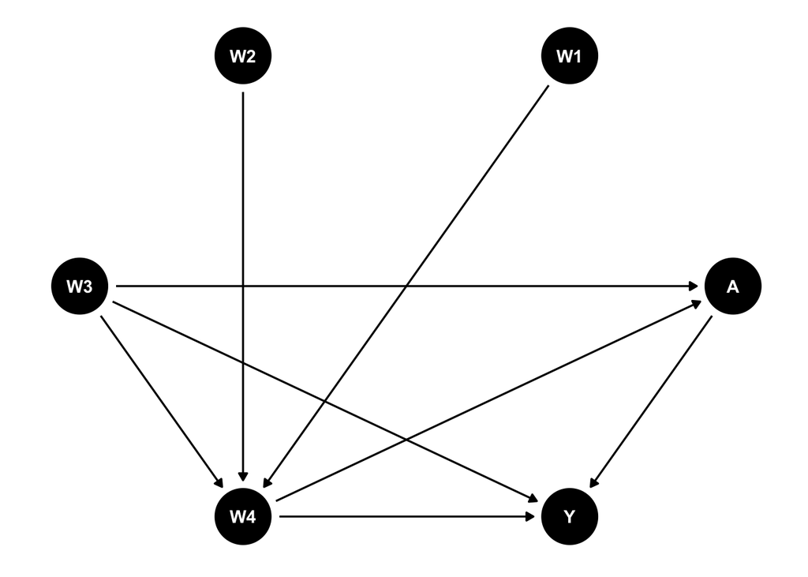

### 6. Estimate.

```r
ObsData <- glottic
n <- nrow(ObsData)

# W1={Female, Male}, W2={Black, White, Others}, W_3={Age},
# W_4={T1a, T1b, T1NOS, T2}, A={Surgery, Radiation},
# Y={survival}.
names(ObsData) <- c("W4", "W1", "W3", "W2", "Y", "A")

ObsData$Y <- as.numeric(ObsData$Y) - 1
ObsData$A <- as.numeric(ObsData$A) - 1

head(ObsData)
```

```
## # A tibble: 6 x 6
##   W4    W1        W3 W2        Y     A
##   <fct> <fct>  <dbl> <fct> <dbl> <dbl>
## 1 T1a   Male      58 White     0     0
## 2 T1b   Male      71 White     0     0
## 3 T1NOS Male      58 Black     0     0
## 4 T1a   Male      52 White     0     0
## 5 T1a   Male      75 White     0     0
## 6 T1a   Female    50 White     0     0
```

#### 1. G-computation

```r
glm.gcomp <- glm(Y ~ A + W3 + W4, family = "binomial", data = ObsData)
glm.gcomp$coef
```

```
## (Intercept)           A          W3       W4T1b     W4T1NOS        W4T2
## -5.17090303  0.40060084  0.02753597  0.53061145 -0.29959813  0.90183271
```

```r
trt <- ObsData %>%
    mutate(A = 1)
ctrl <- ObsData %>%
    mutate(A = 0)

predict.trt <- predict(glm.gcomp, newdata = trt, type = "response")
predict.ctrl <- predict(glm.gcomp, newdata = ctrl, type = "response")
G_comp <- mean(predict.trt - predict.ctrl)
G_comp
```

```
## [1] 0.02032979
```

- Use Super Learner for G-computation

```r
library(SuperLearner)
library(tidyverse)

SL_library <- c("SL.glm", "SL.step", "SL.glm.interaction", "SL.mean")

X = dplyr::select(ObsData, A, W3, W4)
X1 <- X %>%
    mutate(A = 1)
X0 <- X %>%
    mutate(A = 0)

SL_gcomp <- SuperLearner(ObsData$Y, X, SL.library = SL_library,
    cvControl = list(V = 10), family = "binomial")

mAW <- predict(SL_gcomp, newdata = X)$pred
m1W <- predict(SL_gcomp, newdata = X1)$pred
m0W <- predict(SL_gcomp, newdata = X0)$pred

theta.gcomp.SL <- mean(m1W - m0W)
theta.gcomp.SL
```

```
## [1] 0.01510243
```

#### 2. Standard (unstabilized) inverse probability weighted estimator (IPTW)

- Examine the distribution of the predicted probabilities.

```r
# 1.  Estimate the treatment mechanism P(A|W)
prob.AW.reg <- glm(A ~ W3 + W4, family = "binomial", data = ObsData)
prob.AW.reg$coef
```

```
## (Intercept)          W3       W4T1b     W4T1NOS        W4T2
## 0.803649629 0.002595763 0.745943558 0.230830210 0.892563210
```

```r
# 2. Predicted probability of having scurvy
prob.1W <- predict(prob.AW.reg, type = "response")
prob.0W <- 1 - prob.1W
prob.AW <- rep(NA, n)
prob.AW[ObsData$A == 1] <- prob.1W[ObsData$A == 1]
prob.AW[ObsData$A == 0] <- prob.0W[ObsData$A == 0]
summary(prob.AW)
```

```
##    Min. 1st Qu.  Median    Mean 3rd Qu.    Max.
##  0.1268  0.7178  0.7312  0.6645  0.8479  0.8778
```

- Create a vector wt as the inverse of the predicted probabilities.

```r
# Each subject gets a weight inverse weight inverse to pred
# prob
wt <- 1/prob.AW
# look at the distribution of weights
summary(wt)
```

```
##    Min. 1st Qu.  Median    Mean 3rd Qu.    Max.
##   1.139   1.179   1.368   2.000   1.393   7.888
```

- Evaluate the IPTW estimand by taking the empirical mean of the weighted outcomes

```r
IPTW <- mean(wt * as.numeric(ObsData$A == 1) * ObsData$Y) - mean(wt *
    as.numeric(ObsData$A == 0) * ObsData$Y)
IPTW
```

```
## [1] 0.01457439
```

```r
# Arbitrarily truncate the weights at 4
wt.trunc <- wt
wt.trunc[wt.trunc > 4] <- 4

# evaluate the IPTW estimand with the truncated weights
mean(wt.trunc * as.numeric(ObsData$A == 1) * ObsData$Y) - mean(wt.trunc *
    as.numeric(ObsData$A == 0) * ObsData$Y)
```

```
## [1] 0.03138397
```

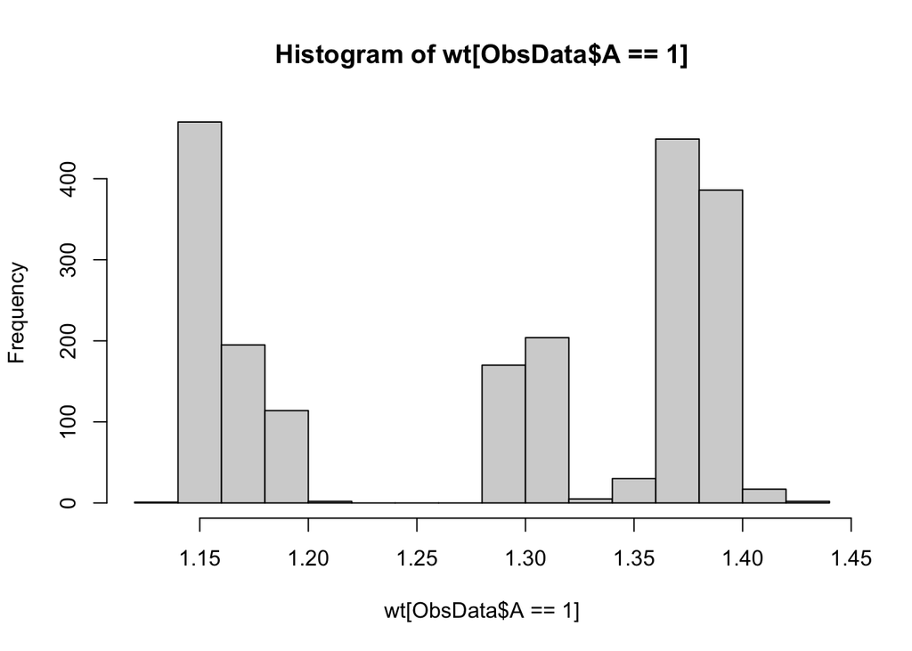

```r
hist(wt[ObsData$A == 1])
```

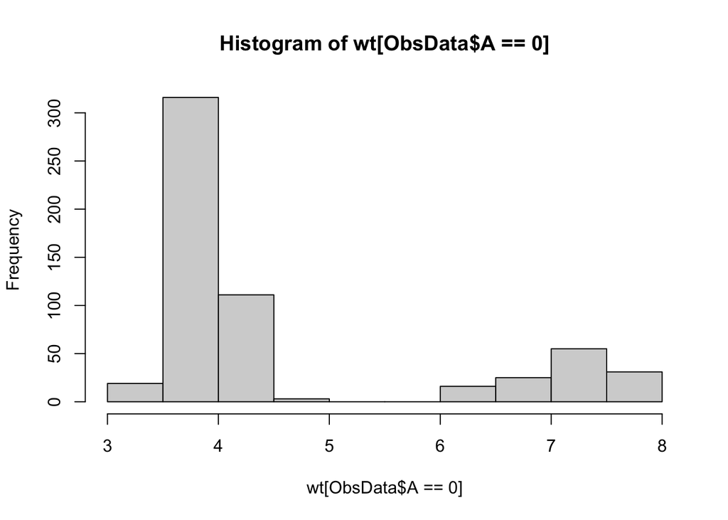

```r
hist(wt[ObsData$A == 0])
```

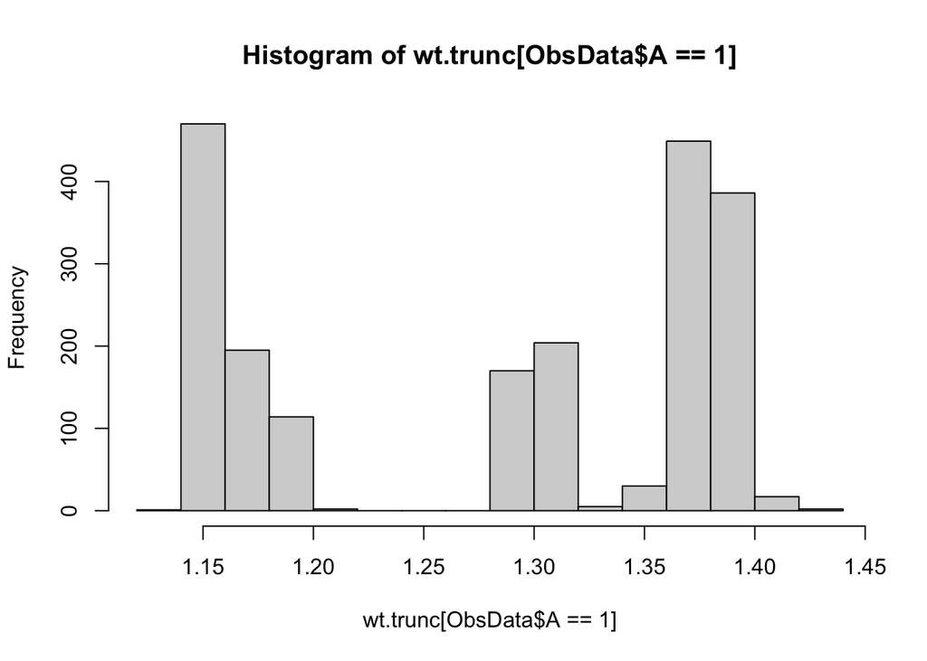

```r
hist(wt.trunc[ObsData$A == 1])
```

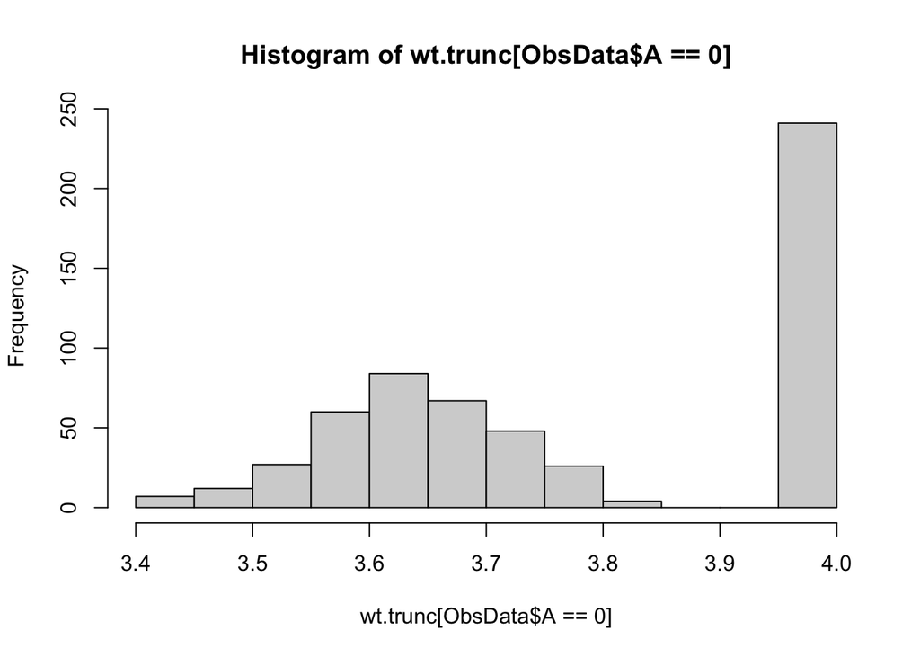

```r
hist(wt.trunc[ObsData$A == 0])
```

- Super Learner for IPTW

```r
Y = ObsData$A
X = dplyr::select(ObsData, W3, W4)
SL_IPTW <- SuperLearner(Y, X, SL.library = SL_library, cvControl = list(V = 10),
    family = "binomial")

g_1W <- SL_IPTW$SL.predict
g_0W <- 1 - g_1W

H_AW <- as.integer(ObsData$A == 1)/g_1W - as.integer(ObsData$A ==
    0)/g_0W

IPTW.SL <- mean(H_AW * ObsData$Y)
IPTW.SL
```

```
## [1] 0.01706238
```